# Exercise Solution for Chapter 11

Mikaela Elder

2020-05-12

To begin, we want to load (or download) the packages we will need for this exercise using `library`:

```r
library(tidyverse)
# BiocManager::install("EBImage")
library(EBImage)
# install.packages("spatstat")
library("spatstat")
```

## Extending the analysis in section 11.17 for all cell types

This exercise asks us to analyze an image of a lymph node and evaluate the spatial dependence for all of the cell types in the lymph node. In this case, the null hypothesis is that each of the cell types are evenly distributed (via a homogenous Poisson process) throughout the lymph node. The cell types we will look at are T cells (T_cells), tumor cells (Tumor), dendritic cells (DCs), and other cells (other_cells).

# The image data

The image data has already been processed from the original image of a stained lymph node slide to a data type known as marked point process. This example uses the following files from the *Modern Statistics for Modern Biology*’s data folder: “99_452SD-DCs.txt”, “99_452SD-other_cells.txt”, “99_452SD-T_cells.txt”, and "“99_452SD-Tumor.txt”.

# Overview of the data

Taking a look at the first few rows

```r
head(brcalymphnode)
```

```
## # A tibble: 6 x 3
##       x     y class
##   <dbl> <dbl> <fct>
## 1  6355 10382 T_cells
## 2  6356 10850 T_cells
## 3  6357 11070 T_cells
## 4  6357 11082 T_cells
## 5  6358 10600 T_cells
## 6  6361 10301 T_cells
```

How many cells are in each cell type?

```r
table(brcalymphnode$class)
```

```
##
##         DCs other_cells     T_cells       Tumor
##         878       77081      103681       27822
```

Visualizing the data for each cell type using ggplot

```r
ggplot(filter(brcalymphnode, class %in% cellclasses),
       aes(x = x, y = y, col = class)) + geom_point(shape = ".") +
  facet_wrap( . ~ class) + guides(col = FALSE)
```

[figure not shown]

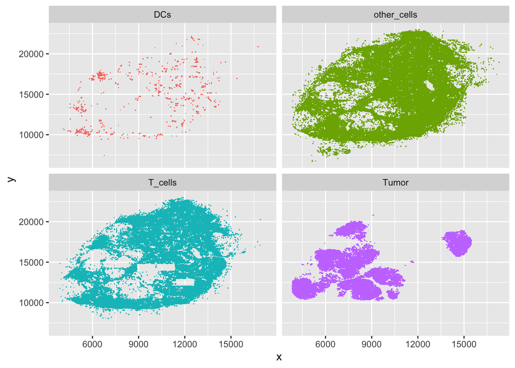

Now that we are familiar with what the data looks like, we will prepare it to be analyzed using the spatstat package, which allows us to put the data into a “ppp” object. The authors of the book describe the advantage of a “ppp” object by its ability to “capture realizations of a spatial point process,” which is convenient to work with when our data is formatted as individual points in the xy plane.

The first step in this process is to change the class of our dataframe into a “ppp” object, which is found in the `spatstat` package.

```r
# put our current dataframe into a ppp object named ln
ln = with(brcalymphnode,
          ppp(x = x, y = y, marks = class, xrange = range(x), yrange = range(y)))
# calling the object gives us summary statistics
ln
```

```
## Marked planar point pattern: 209462 points
## Multitype, with levels = DCs, other_cells, T_cells, Tumor
## window: rectangle = [3839, 17276] x [6713, 23006] units
```

We can create a tighter region to be analyzed by creating a convex hull. This way we are analyzing the shape of the lymph node instead of a rectangle that would be inconsistent with the shape of the image we are interested in analyzing.

```r
# the book uses the convhulln function to accomplish this, but you can also use the chull function in base R
# the convhulln function is found in the geometry package
library("geometry")
coords = cbind(ln$x, ln$y)
chull = convhulln(coords)

# ppp functions need the hull to be defined as closed polygons
# this is the code the book gives to accomplish this
pidx = integer(nrow(chull) + 1)
pidx[1:2] = chull[1, ]
chull[1, ] = NA
for(j in 3:length(pidx)) {
  wh = which(chull == pidx[j-1], arr.ind = TRUE)
  stopifnot(nrow(wh )== 1)
  wh[, "col"] = 3 - wh[, "col"] ## 2->1, 1->2
  pidx[j] = chull[wh]
  chull[wh[, "row"], ] = NA
}
pidx = rev(pidx)
```

We can visualize the hull by graphing it.

```r
# the book gives the following code
ggplot(tibble(x = ln$x, y = ln$y)[pidx, ], aes(x = x, y = y)) +
  geom_point() + geom_path() + coord_fixed()
```

[figure not shown]

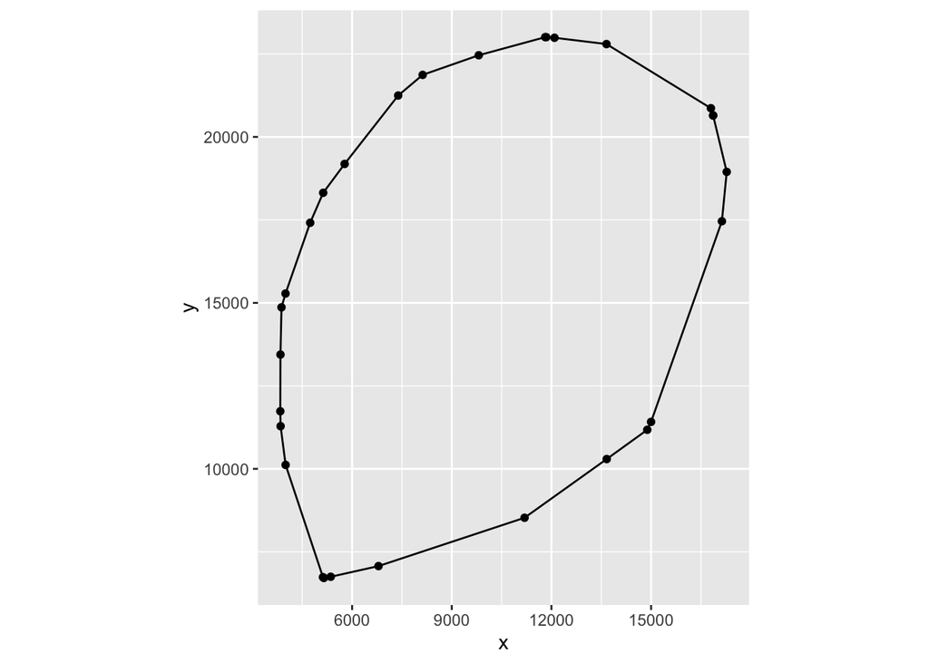

If you compare the shape of the hull to Figure 11.22 in the book, this looks like a better representation of the shape we actually want to analyze.

Now that we have defined the hull as a closed polygon, we can convert our data into a “ppp” object class.

```r
# take brcalymphnode and use its data within the region of the hull and store it in ln
ln = with(brcalymphnode,
          ppp(x = x, y = y, marks = class, poly = coords[ pidx, ],
              check = FALSE))
# calling the object gives a basic summary
ln
```

```
## Marked planar point pattern: 209462 points
## Multitype, with levels = DCs, other_cells, T_cells, Tumor
## window: polygonal boundary
## enclosing rectangle: [3839, 17276] x [6713, 23006] units
```

```r
# to visualize our object, we can plot it
plot(ln, col = 1:4, pch = 19, cex = 0.1)
```

[figure not shown]

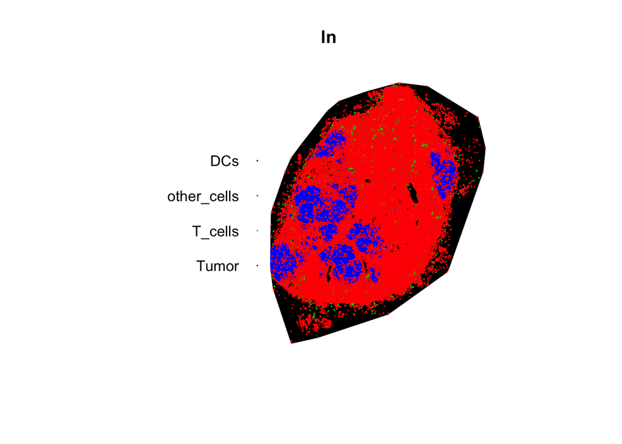

# Investigating Spatial Dependence (our exercise this week from section 11.17)

Now that we have the data in a “ppp” object, we can start to test our null hypothesis that all of the cell types are evenly distributed throughout the lymph node (via a homogenous Poisson process). This will basically allow us to see if there is a spatial dependence in the location of the different cell types. Rejecting our null hypothesis would mean that the cells are spatially dependent on the location of other cells of their type.

If we want to see if a Poisson distribution is a relatively decent assumption with our data, we can use the `Gest` function in the `spatstat` package to look at this. Basically this estimates cumulative distribution function of the distance of a random point to its nearest neighbor. The plot will automatically include the CDF for a homogenous Poisson distribution.

```r
plot(Gest(ln))
```

[figure not shown]

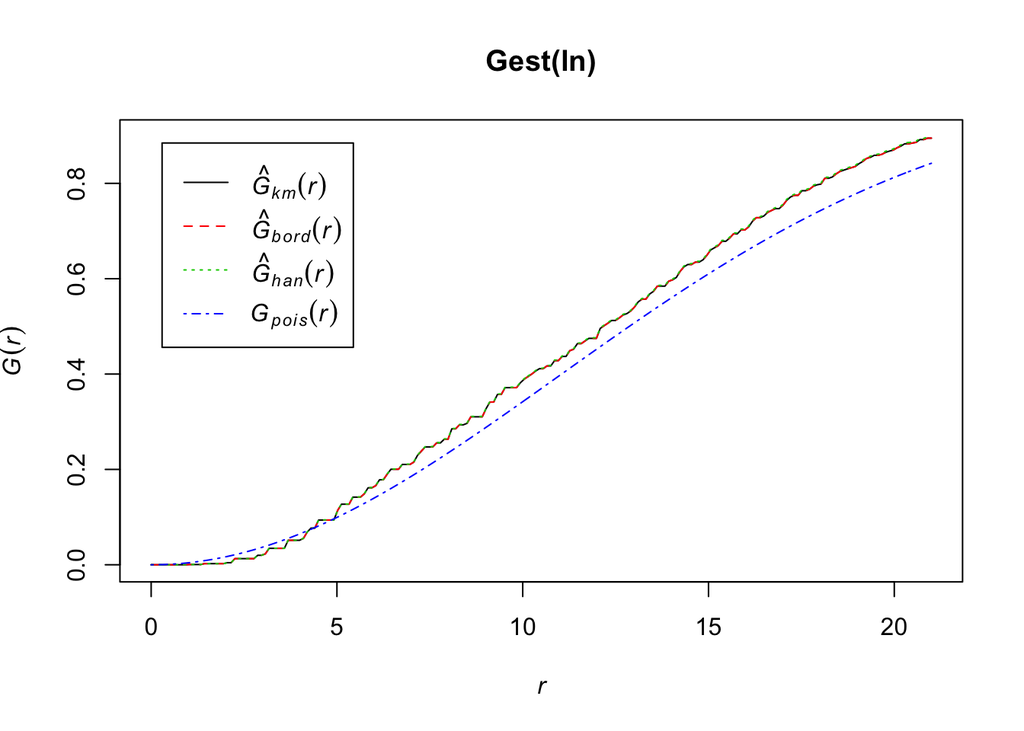

While it looks like our data may differ from a homogenous Poisson CDF, the general shape of our data seems to support this distribution is a fairly reasonable assumption.

If we want to estimate the L function (see equations 11.10 and 11.11 in the book for details), we can use the `Linhom` function in the `spatstat` package. The basic idea is to see if the distance of between cells of a certain type follow a random pattern (represented by Lpois).

T cells:

```r
# estimating the L function for T_cells (this may take a minute to run)
Lln_T_cells <- Linhom(subset(ln, marks == "T_cells"))
```

```
## number of data points exceeds 1000 - computing border correction estimate only
```

```r
# calling the object gives us some descriptions about what each estimate is
Lln_T_cells
```

[output not shown]

[figure not shown]

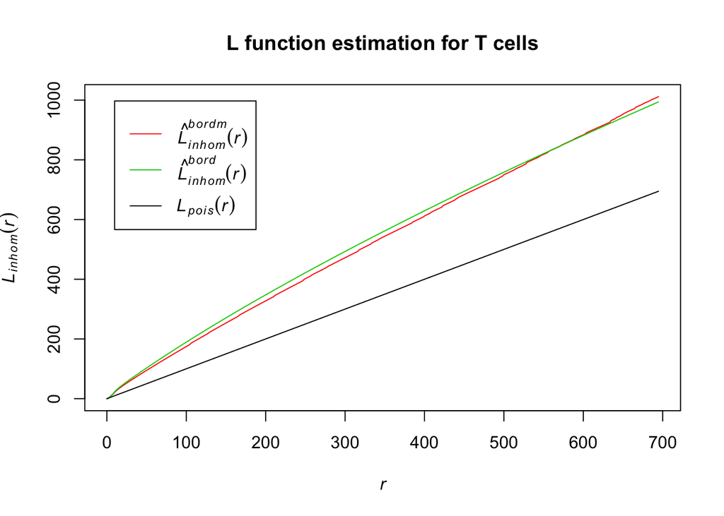

[figure not shown]

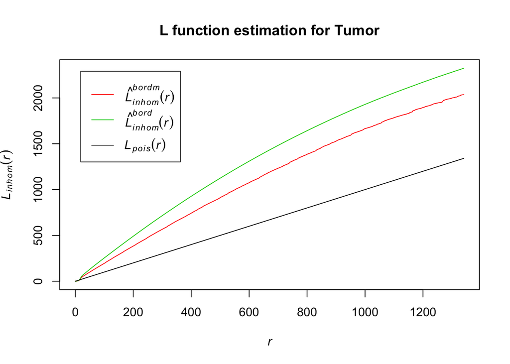

[figure not shown]

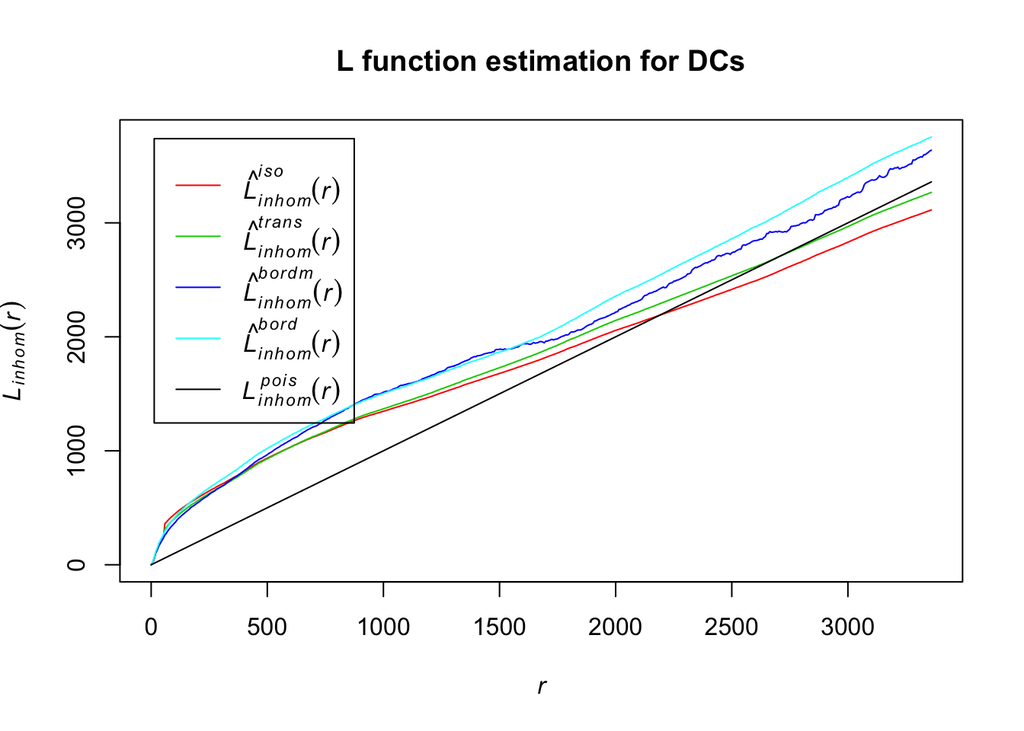

[figure not shown]

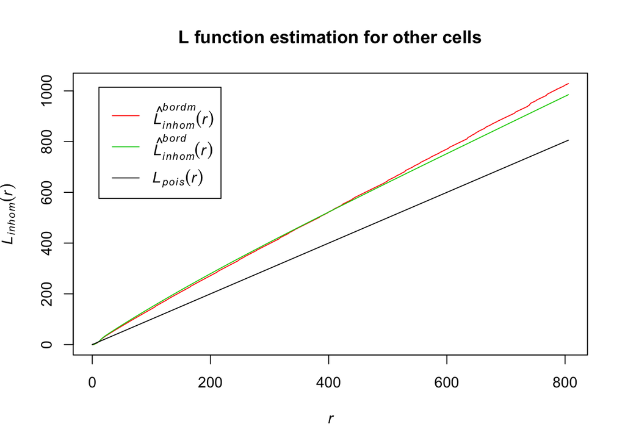

[figure not shown]

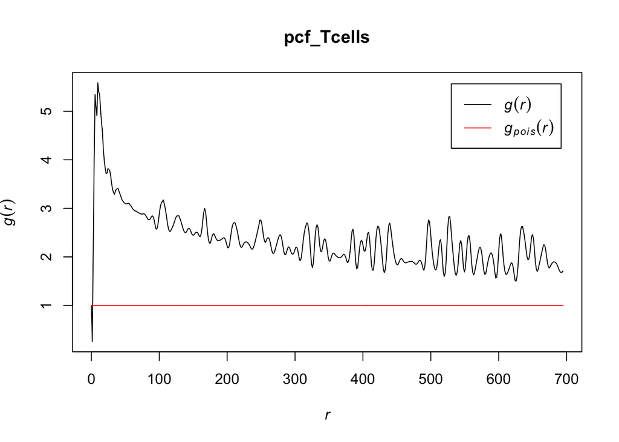

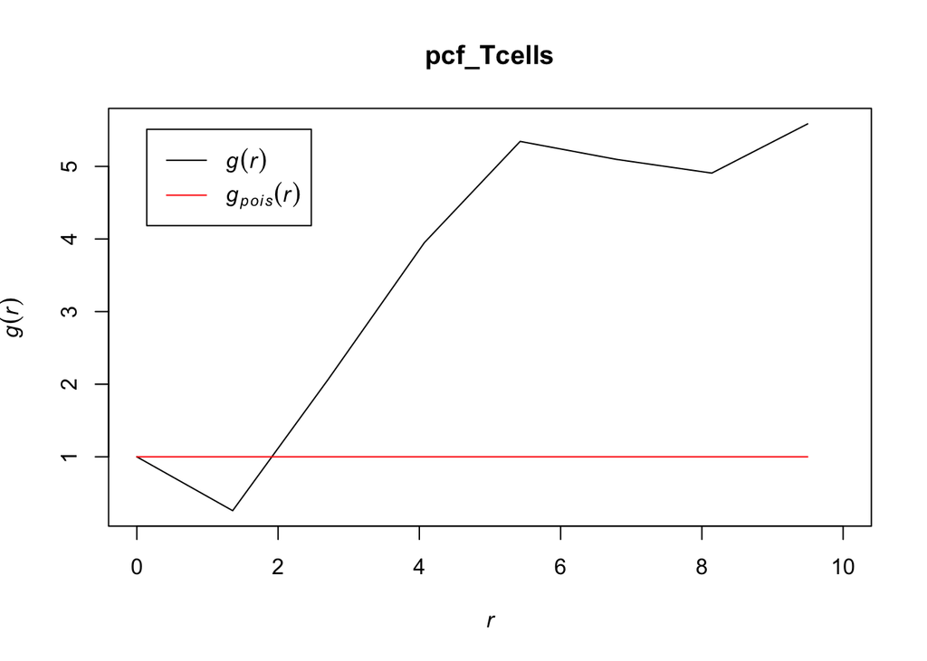

[figure not shown]

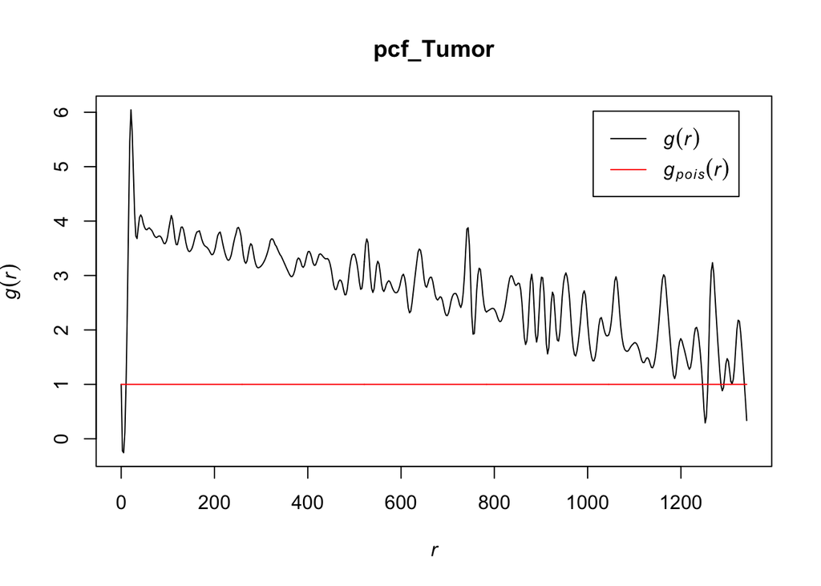

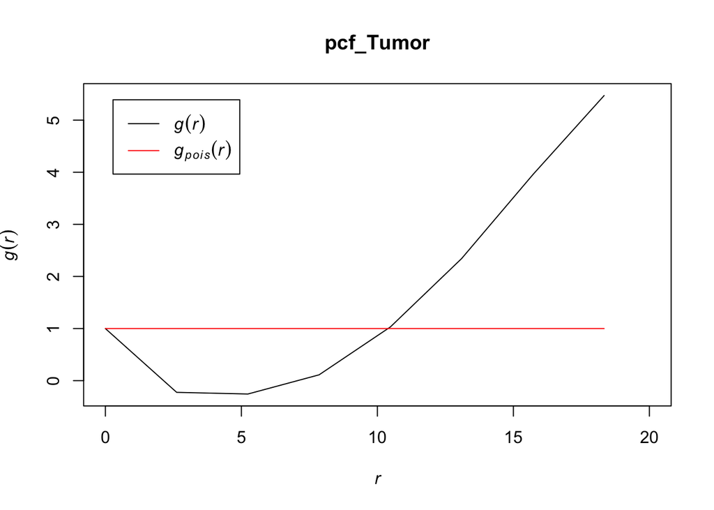

[figure not shown]

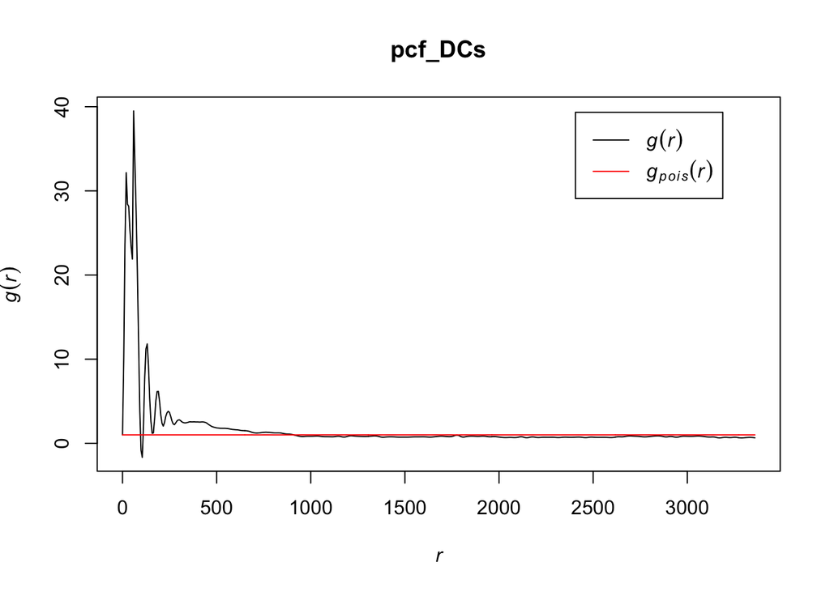

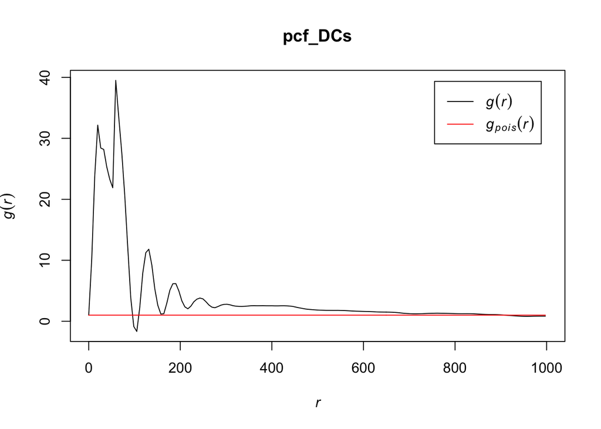

[figure not shown]

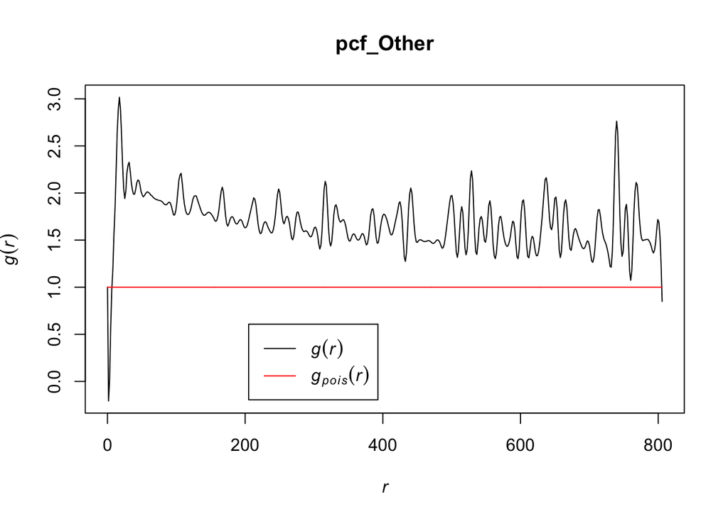

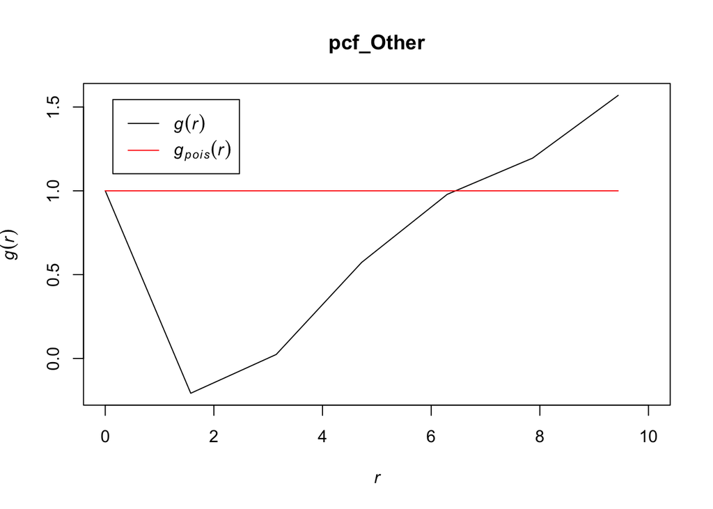

```r
# zooming in to first 10 points
plot(pcf_Other, lty = 1, xlim = c(0, 10))
```

Values for the pcf of ‘other’ cells overall seem to be less than other cell types, indicating that these may be clustering but to a lesser extent than other cell types. The range of values for *r* in which the pcf < 1 are in between what we saw for T cells and tumor cells, indicating that the ‘other’ cells may have volumes in between that of the T cells and the tumor cells that could explain an inhibition in density at those points. It appears as though other cells are also inhomogenously distributed and do not follow a homogenous Poisson process.

Overall, with all cell types, we saw some levels of spatial dependence based on our L function and pcf analyses. For most distances, or values of *r*, we saw differences in the distance and density distributions when comparing a homogenous Poisson distribution to the distribution of each cell type. Depending on a specific amount we consider to be significantly different than our null hypothesis, we may reject our null hypothesis that different cell types are homogenously distributed throughout the lymph node.